# Machine learning assignment

James Black

# 1 Background

Using devices such as Jawbone Up, Nike FuelBand, and Fitbit it is now possible to collect a large amount of data about personal activity relatively inexpensively. These type of devices are part of the quantified self movement - a group of enthusiasts who take measurements about themselves regularly to improve their health, to find patterns in their behavior, or because they are tech geeks. One thing that people regularly do is quantify how much of a particular activity they do, but they rarely quantify how well they do it. In this project, your goal will be to use data from accelerometers on the belt, forearm, arm, and dumbell of 6 participants. They were asked to perform barbell lifts correctly and incorrectly in 5 different ways. More information is available from the website here: http://groupware.les.inf.puc-rio.br/har (see the section on the Weight Lifting Exercise Dataset).

The goal of your project is to predict the manner in which they did the exercise. This is the “classe” variable in the training set. You may use any of the other variables to predict with. You should create a report describing how you built your model, how you used cross validation, what you think the expected out of sample error is, and why you made the choices you did. You will also use your prediction model to predict 20 different test cases.

# 2 Setup

## 2.1 Packages

```r
library(caret)
library(plyr)
library(dplyr)
library(tictoc)

tic() # start the timer
```

## 2.2 Get the data

```r
  data_train <- read.csv(
    url("http://d396qusza40orc.cloudfront.net/predmachlearn/pml-training.csv"),
     na.strings=c("","#DIV/0!","NA") # blank is NA
  )
  data_test <- read.csv(
    url("http://d396qusza40orc.cloudfront.net/predmachlearn/pml-testing.csv"),
     na.strings=c("","#DIV/0!","NA") # blank is NA
  )
```

# 3 Describe the data

```r
# Size
dim(data_train)
```

```
## [1] 19622   160
```

```r
dim(data_test)
```

```
## [1]  20 160
```

```r
# Missing data?
sapply(data_train, function(x) sum(is.na(x)))
```

[output not shown]

[output cut: 53 more lines]

```
##                    19300                        0                    19216
##         avg_roll_forearm      stddev_roll_forearm         var_roll_forearm
##                    19216                    19216                    19216
##        avg_pitch_forearm     stddev_pitch_forearm        var_pitch_forearm
##                    19216                    19216                    19216
##          avg_yaw_forearm       stddev_yaw_forearm          var_yaw_forearm
##                    19216                    19216                    19216
##          gyros_forearm_x          gyros_forearm_y          gyros_forearm_z
##                        0                        0                        0
##          accel_forearm_x          accel_forearm_y          accel_forearm_z
##                        0                        0                        0
##         magnet_forearm_x         magnet_forearm_y         magnet_forearm_z
##                        0                        0                        0
##                   classe
##                        0
```

```r
sapply(data_test, function(x) sum(is.na(x)))
```

[output not shown]

[output cut: 53 more lines]

```
##                       20                        0                       20
##         avg_roll_forearm      stddev_roll_forearm         var_roll_forearm
##                       20                       20                       20
##        avg_pitch_forearm     stddev_pitch_forearm        var_pitch_forearm
##                       20                       20                       20
##          avg_yaw_forearm       stddev_yaw_forearm          var_yaw_forearm
##                       20                       20                       20
##          gyros_forearm_x          gyros_forearm_y          gyros_forearm_z
##                        0                        0                        0
##          accel_forearm_x          accel_forearm_y          accel_forearm_z
##                        0                        0                        0
##         magnet_forearm_x         magnet_forearm_y         magnet_forearm_z
##                        0                        0                        0
##               problem_id
##                        0
```

There are a lot of missing variables. I’ll delete the columns with 50% or more missing.

```r
data_train <- data_train[, colSums(is.na(data_train)) < nrow(data_train) * 0.5]
```

# 4 Partition the data

I’ll take a 70% split on the training the validation data.

```r
set.seed(123)
inTrain <- createDataPartition(data_train$classe, p=0.70, list=F)
data_train_fit <- data_train[inTrain, ]
data_train_validate <- data_train[-inTrain, ]
```

# 5 Model fitting

## 5.1 Feature selection

I will use the moderately computationally hungry Recursive Feature Elimination to pick covariates as doing this analysis outside of work hours means speed is very important (rather than manually thinking about the data).

```r
set.seed(123)

# define the control for the RFE using a random forest selection function
control <- rfeControl(functions=rfFuncs, method="cv", number=10)

# run the RFE algorithm
model_rfe <- rfe(
  data_train_fit[,8:59], data_train_fit[,60],
  sizes=c(1:50), # lets keep the top 45
  rfeControl=control)
# summarize the results
print(model_rfe)
```

```
##
## Recursive feature selection
##
## Outer resampling method: Cross-Validated (10 fold)
##
## Resampling performance over subset size:
##
##  Variables Accuracy  Kappa AccuracySD  KappaSD Selected
##          1   0.4948 0.3462   0.013649 0.019327
##          2   0.7288 0.6561   0.010592 0.013388
##          3   0.8928 0.8645   0.009421 0.011896
##          4   0.9419 0.9265   0.005760 0.007297
##          5   0.9643 0.9549   0.004758 0.006015
##          6   0.9777 0.9717   0.002756 0.003480
##          7   0.9796 0.9742   0.004835 0.006112
```

[output cut: 47 more lines]

```r
# list the chosen features
predictors(model_rfe)
```

```
##  [1] "roll_belt"            "yaw_belt"             "magnet_dumbbell_z"
##  [4] "pitch_belt"           "magnet_dumbbell_y"    "pitch_forearm"
##  [7] "accel_dumbbell_y"     "roll_forearm"         "roll_dumbbell"
## [10] "magnet_forearm_z"     "roll_arm"             "accel_dumbbell_z"
## [13] "magnet_dumbbell_x"    "magnet_belt_z"        "gyros_belt_z"
## [16] "magnet_belt_y"        "accel_forearm_x"      "yaw_arm"
## [19] "magnet_belt_x"        "gyros_arm_y"          "accel_forearm_z"
## [22] "yaw_dumbbell"         "gyros_dumbbell_y"     "accel_belt_z"
## [25] "magnet_forearm_y"     "total_accel_dumbbell" "gyros_forearm_y"
## [28] "magnet_arm_z"         "gyros_arm_x"          "accel_forearm_y"
## [31] "yaw_forearm"          "accel_dumbbell_x"     "gyros_dumbbell_x"
## [34] "pitch_arm"            "accel_arm_z"          "magnet_forearm_x"
## [37] "accel_arm_y"          "gyros_forearm_z"      "accel_arm_x"
## [40] "total_accel_forearm"  "gyros_dumbbell_z"     "magnet_arm_x"
## [43] "total_accel_arm"      "magnet_arm_y"         "gyros_belt_x"
```

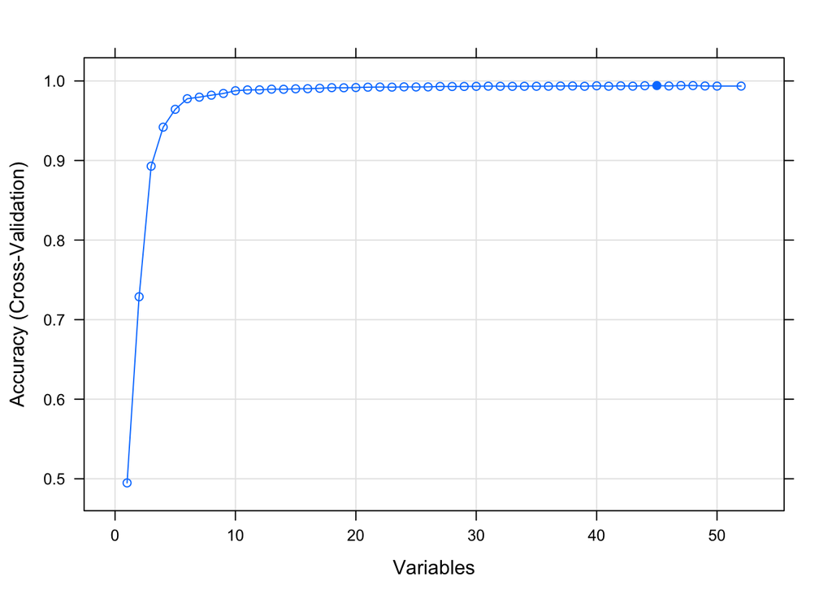

```r
# plot the results
plot(model_rfe, type=c("g", "o"))
```

So my model is pretty good after just 20 variables - so I’ll subset it down to the first 20 when building the model.

## 5.2 Random forest model

I will use **Random Forest** as the outcome is categorical, I want to avoid making assumptions about the data, and the need for imputing the remaining missing values is lessened/removed.

```r
train_control <- trainControl(method="repeatedcv",
                              number=10, # folds
                              repeats=5) # repeats

# subset to covariates
  covariates <- c(predictors(model_rfe)[1:20],"classe")
  covariate_colnumbers <- match(covariates,names(data_train_fit))

  data_train_fit <- data_train_fit %>%
    select(covariate_colnumbers) # cut data to my predictors

model <- train(classe ~ .,
               data=data_train_fit,
               method="rf",
               trControl=train_control,
               ntree=100)
model
```

```
## Random Forest
##
## 13737 samples
##    20 predictor
##     5 classes: 'A', 'B', 'C', 'D', 'E'
##
## No pre-processing
## Resampling: Cross-Validated (10 fold, repeated 5 times)
## Summary of sample sizes: 12361, 12364, 12364, 12363, 12363, 12363, ...
## Resampling results across tuning parameters:
##
##   mtry  Accuracy   Kappa      Accuracy SD  Kappa SD
##    2    0.9905511  0.9880483  0.002895044  0.003662100
##   11    0.9901436  0.9875330  0.002513497  0.003179844
##   20    0.9868533  0.9833712  0.003024928  0.003826535
##
## Accuracy was used to select the optimal model using  the largest value.
## The final value used for the model was mtry = 2.
```

How did it do?

```r
model_predict <- predict(
  model,
  data_train_validate)

confusionMatrix(
  data_train_validate$classe,
  model_predict)
```

```
## Confusion Matrix and Statistics
##
##           Reference
## Prediction    A    B    C    D    E
##          A 1669    5    0    0    0
##          B    9 1120    8    1    1
##          C    1   14 1007    4    0
##          D    0    0   21  942    1
##          E    0    0    1    1 1080
##
## Overall Statistics
##
##                Accuracy : 0.9886
##                  95% CI : (0.9856, 0.9912)
##     No Information Rate : 0.2853
##     P-Value [Acc > NIR] : < 2.2e-16
##
##                   Kappa : 0.9856
##  Mcnemar's Test P-Value : NA
##
## Statistics by Class:
##
##                      Class: A Class: B Class: C Class: D Class: E
## Sensitivity            0.9940   0.9833   0.9711   0.9937   0.9982
## Specificity            0.9988   0.9960   0.9961   0.9955   0.9996
## Pos Pred Value         0.9970   0.9833   0.9815   0.9772   0.9982
## Neg Pred Value         0.9976   0.9960   0.9938   0.9988   0.9996
## Prevalence             0.2853   0.1935   0.1762   0.1611   0.1839
## Detection Rate         0.2836   0.1903   0.1711   0.1601   0.1835
## Detection Prevalence   0.2845   0.1935   0.1743   0.1638   0.1839
## Balanced Accuracy      0.9964   0.9897   0.9836   0.9946   0.9989
```

```r
postResample(model_predict, data_train_validate$classe)
```

```
##  Accuracy     Kappa
## 0.9886151 0.9855974
```

So, the model works!

## 5.3 Predicting for Test Data Set

Now - see what it predicts the 20 in the test set will be.

```r
predict(model, data_test)
```

```
##  [1] B A B A A E D B A A B C B A E E A B B B
## Levels: A B C D E
```